# A multi-domain self-report assessment of health in adults with and without hearing loss

### Preparing the dataset

**Initial steps**

1. Downloaded data from Qualtrics (numeric version, in .csv format), on July 2, 2020. Recorded responses n = 553.
2. Deleted second and third header rows (rows 2 and 3).
3. Sort by column “Consent_1_main”, and deleted participants who declined to participate; i.e. responded with option 2 or 3 (n = 26). Note: leaves 527 participants.
4. Created Qualtrics ID “key” for matching with Connect IDs, with five columns: ResponseId, RecipientLastName, RecipientFirstName, Consent_1_main, Consent_2_clinic; file named “id_qualtrics.csv”.
5. Deleted columns from main Qualtrics dataset: IPAddress, RecipientLastName, RecipientFirstName, RecipientEmail, ExternalReference, LocationLatitude, LocationLongitude, DistributionChannel, UserLanguage
6. Matched Connect IDs to Qualtrics IDs using first and last names.
7. Matched audiometric and other clinic info to Qualtrics data using Qualtrics IDs.

### Evaluating data quality

Of 527 respondents: 453 were matched to Connect IDs; 6 were matched but declined to share info; 2 were matched but did not fill out consent option to share info and are assumed to have declined; 66 were unmatched to Connect IDs (see “cases.pdf”).

Of those 453 who consented to share their clinic data and had clinic IDs available, 439 had full audiograms, 3 had a few cells missing from their audiograms, and 11 had completely missing audiograms. Of the 11 completely missing audiograms, 7 were recovered from the original Connect 1 dataset (before any cleaning). Final result: 446 full audiograms, 3 partial, 4 missing.

### Read current dataset

Qualtrics_data_2020.07.13.csv

### Data inclusion criterion

“Non-conditional items” are items in the questionnaire that make up the shortest possible path through the survey, i.e., skipping all conditional items that only appear given a ‘yes’ answer earlier. The threshold we decided on for including a participant’s data is that they should have less than 10% missing cells in non-conditional items. Using this threshold, 497 (94.3%) participants are included.

*Proportion_missing_data* and *Include_over90data* are added as new variables.

```
## [1] 497
```

```
## [1] 0.943074
```

### Calculating composite scores

**Current list of composite scores:** - Physical health: Total count of co-morbidities - SSQ15i: Average score, and three average sub-scores - Social Isolation Measure (SIM): Total score - Emo-CheQ four items: Total score - HHIE-S: Total score, and two sub-scores - Cognitive Self-Report Questionnaire (CSRQ): Total score (no info on scoring) - Activities-Specific Balance Confidence Scale: Average score - Satisfaction with Life Scale (SWLS): Average score - WHOQOL-BREF: Specific scoring procedure in manual - Loneliness: Scored according to Mick et al. (2018) - Patient Health Questionnaire (PHQ): Total score - Social Network Index: Sum; scoring procedure in Mick et al. (2018) - Social Participation (CCHS / CLSA): Recoding procedure in Mick et al. (2018) - General Relationship Satisfaction: Total score - MOS Social Support Survey: Scoring procedure in Mick et al. (2018) - PTA4 left, right, and better ear

Unless there were specific rules about how to deal with NAs in a scoring procedure, for averages, I generally used na.rm=TRUE, calculating the average without including any NA cells. For totals, I generally used na.rm=FALSE, setting the row total to be NA if there was one or more NA cells (exceptions are the Social Network Index and Social Participant score calculations).

### Cleaning variables

**Year of birth** *Age* is added as a new variable.

### List of all new variables

```
## 'data.frame':    527 obs. of  36 variables:
##  $ Proportion_missing_data: num  0.03286 0.00469 0 0 0.00469 ...
##  $ Include_over90data     : num  1 1 1 1 1 1 1 1 1 1 ...
##  $ Comorb_count           : num  9 1 1 7 15 3 0 4 3 4 ...
##  $ SSQ15i_avg             : num  8.5 7.5 8.01 7.18 7.96 ...
##  $ SSQ15i_qualities       : num  9.36 7.9 8.64 8.38 8.47 ...
##  $ SSQ15i_spatial         : num  9 7.3 7.92 8.36 7.98 4.96 8.06 NA NA 6.22 ...
##  $ SSQ15i_speech          : num  7.34 7.3 7.46 4.8 7.52 5.98 8.28 NA 9.92 5.88 ...
##  $ SIM_total              : num  5 6 10 35 8 27 11 0 0 28 ...
##  $ Emocheq4_total         : num  10 7 10 17 5 7 8 6 4 7 ...
##  $ HHIES_total            : num  8 2 4 26 34 8 4 0 0 24 ...
##  $ HHIES_emo              : num  4 0 0 14 18 2 2 0 0 12 ...
##  $ HHIES_soc              : num  4 2 4 12 16 6 2 0 0 12 ...
##  $ CSRQ_total             : num  85 97 85 88 61 92 121 NA 107 84 ...
##  $ ABC_average            : num  80 83.1 96.2 91.9 80 ...
```

[output cut: 22 more lines]

### Number & percentage of participants in each group

Those who are “NA” are not classified because there is no PTA4 information available for them.

```
##
##   HA   HL   NH <NA>
##   62  105  281   79
```

```
##
##   HA   HL   NH <NA>
## 11.8 19.9 53.3 15.0
```

### Descriptive plots

Note: All those with unknown Group and all those with >10% missing data have been excluded for these plots.

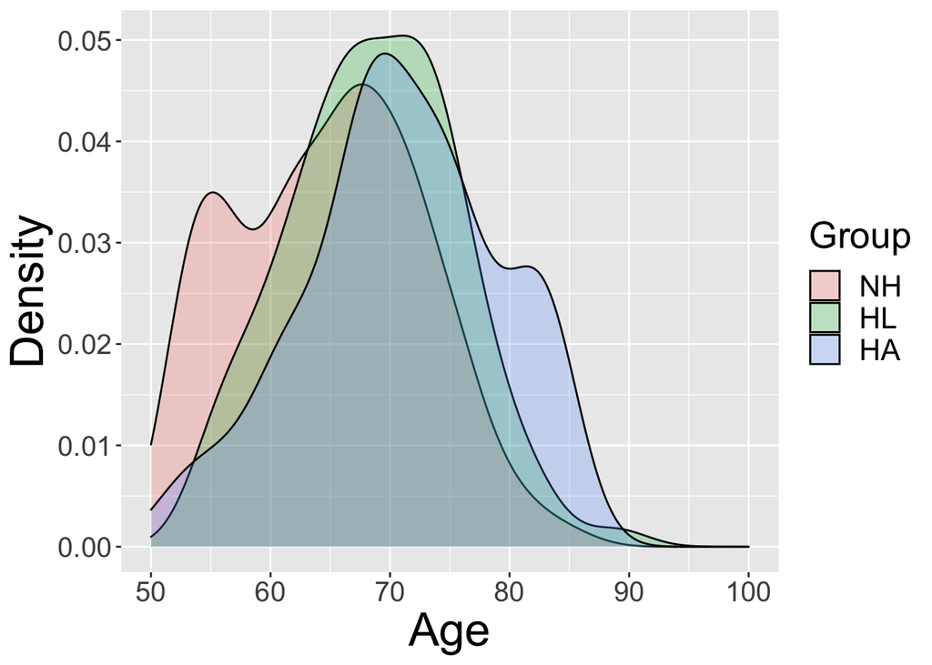

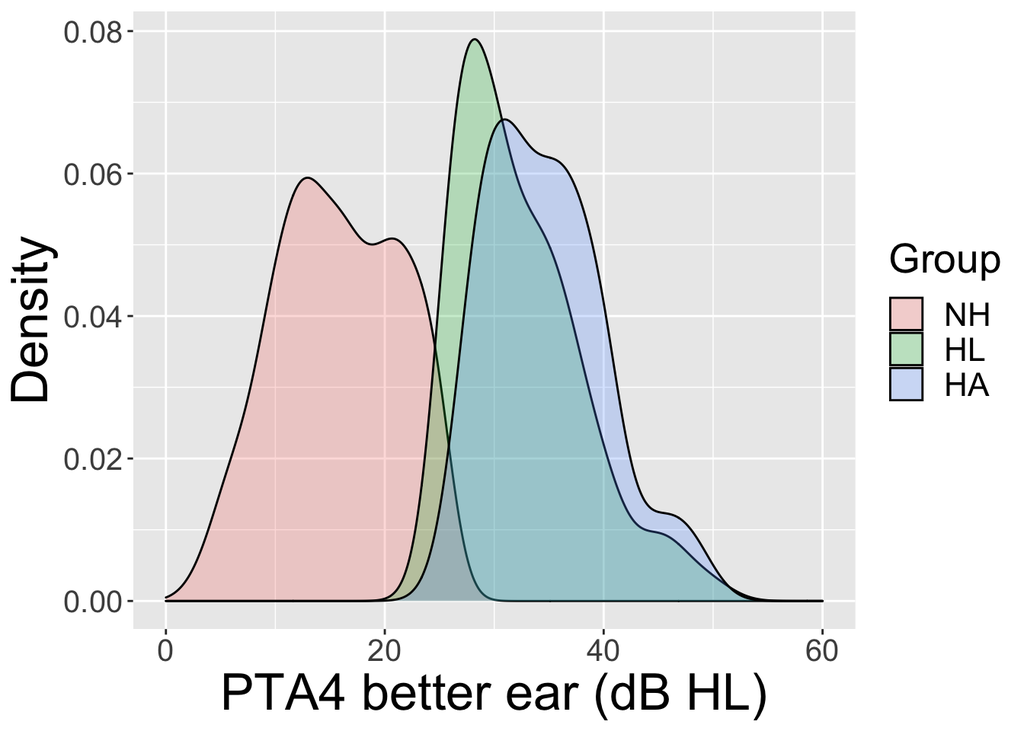

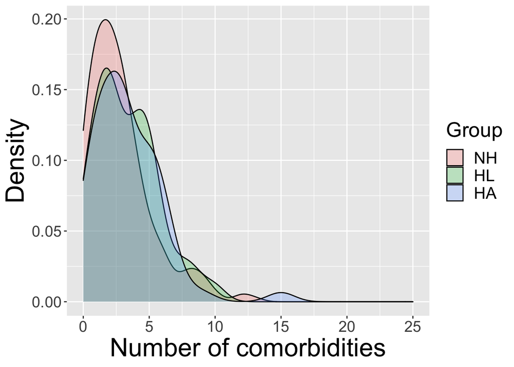

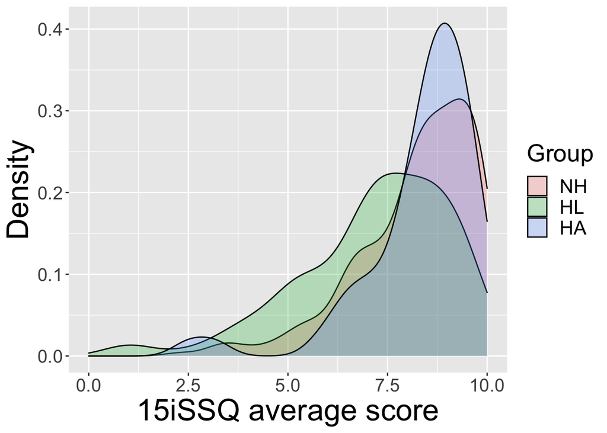

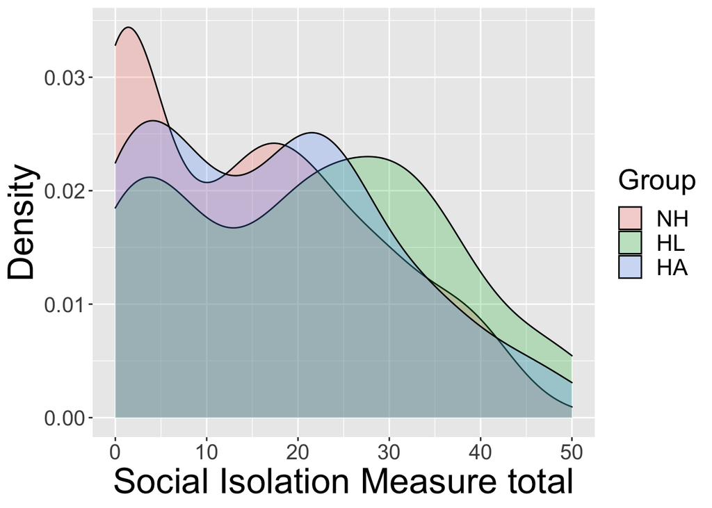

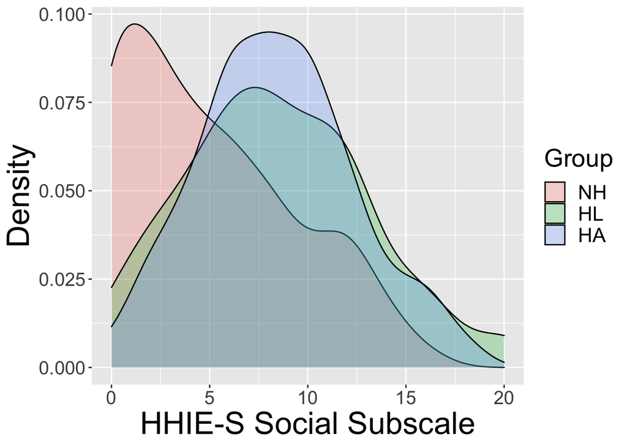

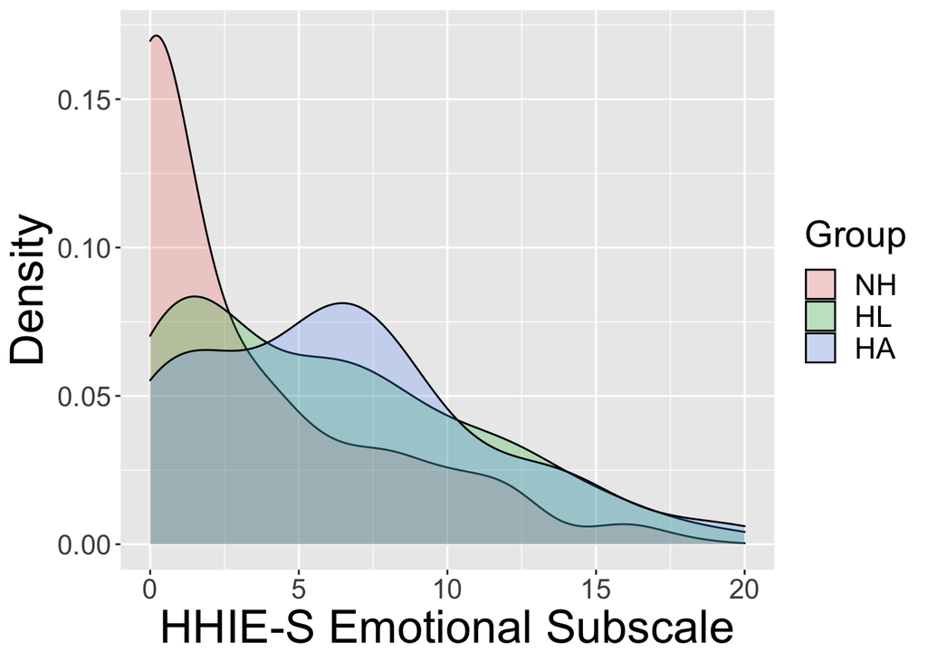

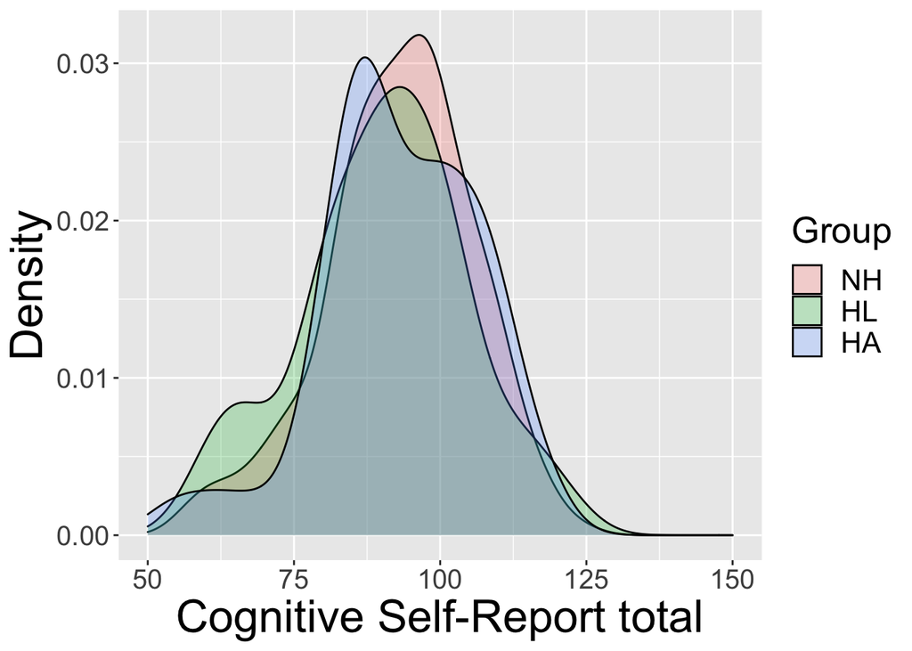

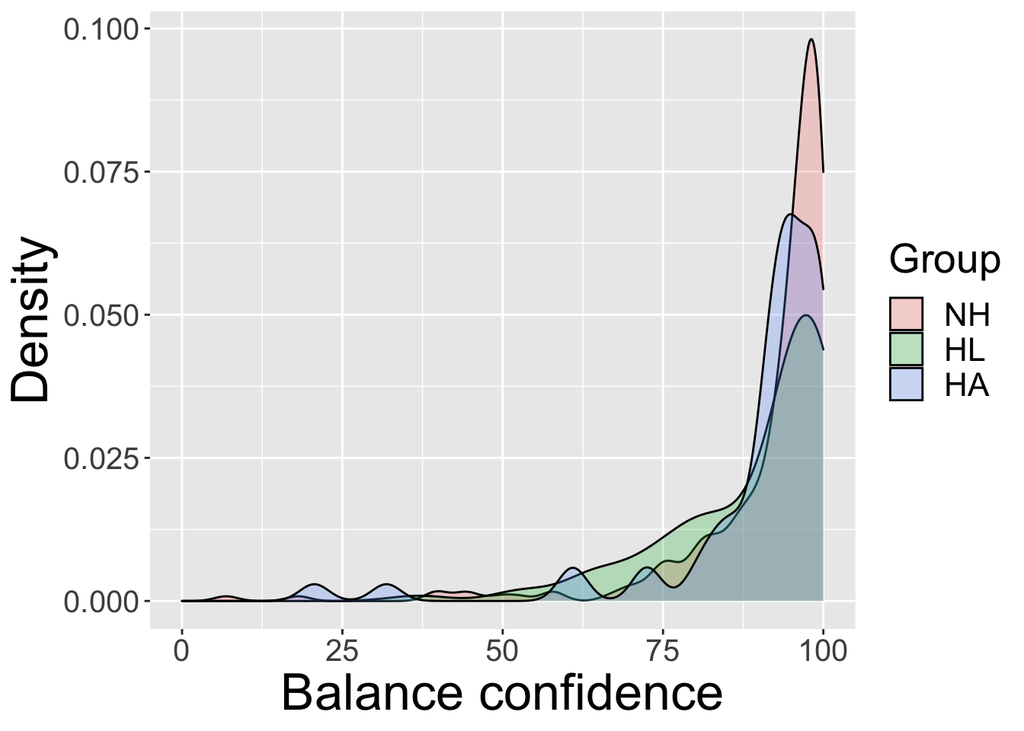

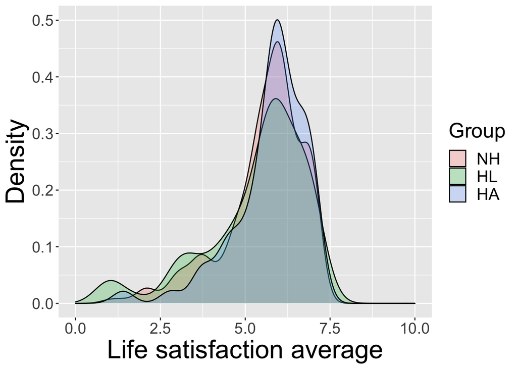

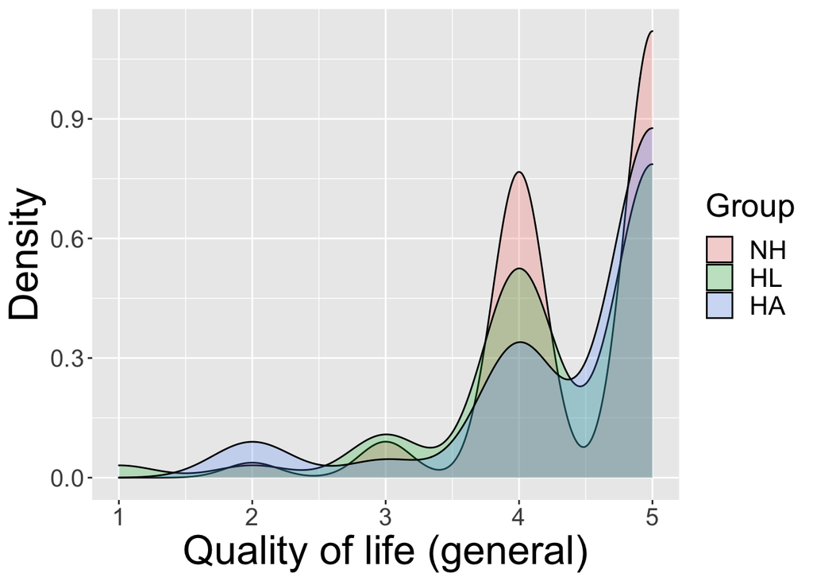

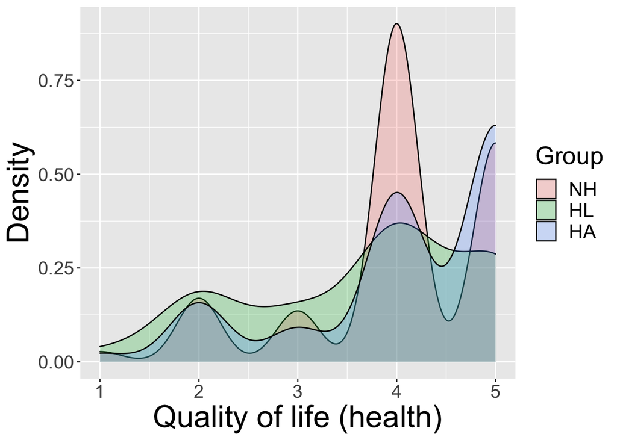

[5 more figures not shown]

**Loneliness**

```
##
##      Not lonely Lonely
##   NH       81.7   18.3
##   HL       71.9   28.1
##   HA       83.3   16.7
##   NA
```

**Social participation**

Social participation: Including all participants

```
##
##       Low High
##   NH 21.6 78.4
##   HL 18.8 81.2
##   HA 16.7 83.3
##   NA
```

Social participation: Only including those who are retired

```
##
##       Low High
##   NH 18.0 82.0
##   HL 10.8 89.2
##   HA 10.0 90.0
##   NA
```

**Correlation among subscales of MOS Social Support**

```
##                      ScSppMOS_m ScSppMOS_t ScSppMOS_f ScSppMOS_p
## SocSuppMOS_emoinfo   1.00
## SocSuppMOS_tangible  0.68       1.00
## SocSuppMOS_affection 0.74       0.72       1.00
## SocSuppMOS_positive  0.85       0.73       0.81       1.00
```

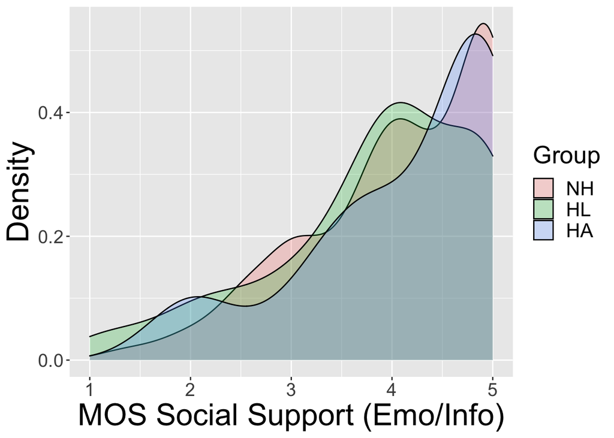

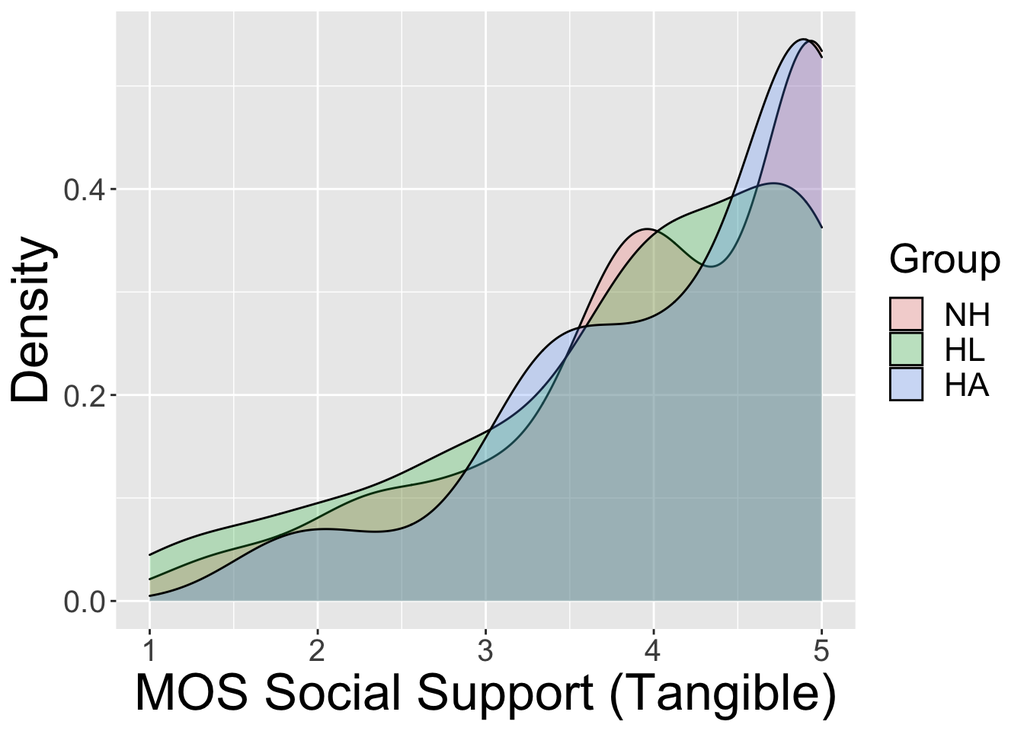

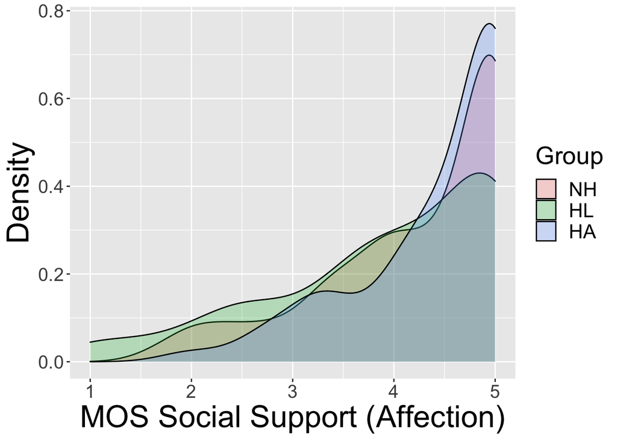

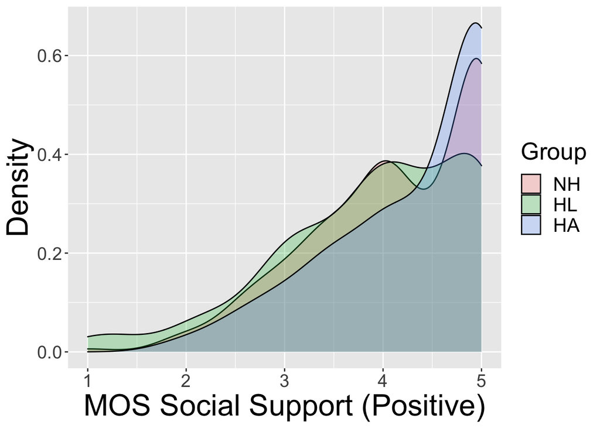

### Change in loneliness

The same question on loneliness was asked in Connect 1 as in Connect 2: “In the past week, how often did you feel lonely? All of the time, Occasionally, Some of the time, Rarely or never.”

### Loneliness, social support, HHIE subscales, SSQ